# AGEC 936 - Module 1

Difference-in-Differences (DID) Two-way Fixed Effects (TWFE)

Jisang Yu  
Kansas State University

# This week

- Difference-in-differences (DID) in potential outcome framework
- Two-way Fixed Effects (TWFE)
- Parallel trend assumption
- Staggered treatment timing: When can TWFE fail and some alternatives

# Potential outcome representation

- With a binary treatment, $d_i=\{0,\;1\}$, let us denote the outcome of interest as
  $$y_i(0)\;\text{if}\;d_i=0 \\
  y_i(1)\;\text{if}\;d_i=1$$
- With an *ideal* research design, the difference,
  $$y_i(1)-y_i(0)$$
  can be interpreted as **causal effect** (Rubin 1974). In practice, **do we observe both $y_i(0)$ and $y_i(1)$**?
- The *ideal* average treatment (causal) effect is defined as
  $$E(y_i(1)-y_i(0))=E(y_{i}(1))-E(Y_{i}(0)).$$
- Instead, we observe
  $$y_i=y_i(0)+(y_i(1)-y_i(0))d_{i}.$$
  and can estimate
  $$E(y_{i}|d_i=1)-E(y_{i}|d_i=0).$$
- What happens if $y_i(0)$, $y_i(1)$, and $d_i$ are not independent?
  $$E(y_{i}|d_i=1)-E(y_{i}|d_i=0) \\
  =E(y_i(0)+(y_i(1)-y_i(0))|d_i=1)-E(y_i(0)|d_i=0) \\
  =(E(y_i(1)|d_i=1)-E(y_i(0)|d_i=1))+(E(y_i(0)|d_i=1)-E(y_i(0)|d_i=0)).$$
  If the **Bias** term is non-zero, what should we do?

# Difference-in-differences (DID)

- **Set-up** Let’s consider 2 x 2 case (two-period, $t={1,2}$, N-unit, $i={1,...,N}$, and two-group, $g={T,C}$ case). Potential outcomes are
  $$y_{it}(0)=\alpha_i+\gamma_t+\varepsilon_{it} \\
  y_{it}(1)=\alpha_i+\gamma_t+\tau_i+\varepsilon_{it}$$
  For $i \in T$, $d_{i1}=0$ and $d_{i2}=1$ and for $i \in C$, $d_{i1}=0$ and $d_{i2}=0$.
- **Average Treatment Effect on Treated (ATT)**
  $$E(\tau_i|i \in T)$$
  This is normally what we want!
- **First differences**
  $$y_{i2}-y_{i1}=(\alpha_i+\gamma_2+\tau_i d_{i2}+\varepsilon_{i2}) -
  (\alpha_i+\gamma_1+\tau_i d_{i1}+\varepsilon_{i1}) \\
  =(\gamma_2-\gamma_1)+\tau_i
  (d_{i2}-d_{i1})+(\varepsilon_{i2}-\varepsilon_{i1})$$
  Conditional expectations by group:
  $$E(y_{i2}-y_{i1}|i \in T)=(\gamma_2-\gamma_1)+E(\tau_i (d_{i2}-d_{i1})|i
  \in T)+E(\varepsilon_{i2}-\varepsilon_{i1}|i \in T) \\
  =(\gamma_2-\gamma_1)+E(\tau_i |i \in T)$$
  $$E(y_{i2}-y_{i1}|i \in C)=(\gamma_2-\gamma_1)+E(\tau_i (d_{i2}-d_{i1})|i
  \in C)+E(\varepsilon_{i2}-\varepsilon_{i1}|i \in C) \\
  =(\gamma_2-\gamma_1)$$
- **Difference-in-differences**
  $$E(y_{i2}-y_{i1}|i \in T)-E(y_{i2}-y_{i1}|i \in C)
  =\{(\gamma_2-\gamma_1)+E(\tau_i |i \in T)\}-(\gamma_2-\gamma_1) \\
  =E(\tau_i |i \in T)$$

# Two-way Fixed Effects (TWFE)

- **Two-way Fixed Effects** We can also use the following regression equation:
  $$y_{it}=\alpha_i+\gamma_t+\tau_i d_{it}+\varepsilon_{it}$$
  With $T=2$, the OLS estimator for the equation above, denoted by $\hat{\tau}_{FE}$, is consistently estimating *ATT*. Need the following assumptions:
  - Strict exogeneity
  - Parallel trend
- **“Parallel-trend” assumption**: Revisit the DinD expression,
  $$E(y_{i2}-y_{i1}|i \in T)-E(y_{i2}-y_{i1}|i \in C)
  =\{(\gamma_2-\gamma_1)+E(\tau_i |i \in T)\}-(\gamma_2-\gamma_1) \\
  =E(\tau_i |i \in T)$$
  This is valid if
  $$\gamma_{it}=\gamma_{t}\;\text{for}\;\forall\;i.$$

# A simulation: the equivalence between DID and TWFE

- **DGP**
  $$y_{it}=5+2(t-1)+4d_{it}+0.2x_{i}+\varepsilon_{it}\;\;\text{with}\;\;i=\{1,2,...,500\}\;\;\text{and}\;\;t=\{1,2\}$$
  $$d_{i1}=0,\;\;
  d_{i2}= \begin{cases}
  1\;\;\text{if}\;\;i=\{1,...,250\} \\
  0\;\;\text{otherwise}
  \end{cases}$$
  $$x_{i}=\begin{cases}
  0.5+u_{i}\;\;\text{if}\;\;i=\{1,...,250\} \\
  u_{i}\;\;\text{otherwise}
  \end{cases}
  \;\;\text{and}\;\;u_i \sim N(0,1)$$

```r
library(lmtest)
library(sandwich)
# set seed
set.seed(11123)

# 500 units
N<-500
unit<-1:500

# Define treatment effect
tau<-4

# Treatment groups
d <- c(rep(0, N/2), rep(1, N/2))

# DGP
X <- d*0.5+rnorm(N)
# Pre
Y_1 <- 5+0.2*X+0.3*rnorm(N)
# Post
Y_2 <- 5+2+0.2*X+tau*d+0.3*rnorm(N)

# DinD
(mean(Y_2[d == 1]) - mean(Y_1[d == 1])) - (mean(Y_2[d == 0]) - mean(Y_1[d == 0]))
```

```
[1] 4.027091
```

```r
# Two-way Fixed Effects
# Data prep
dind_data <- data.frame("Y"=c(Y_1, Y_2),
                        "Treat"=c(rep(0,N), d),
                        "Unit"=c(unit, unit),
                        "Time"=c(rep(1,N), rep(2,N)))

# Two-way FE regression
TWFE <- lm(Y ~ Treat + as.factor(Time) + as.factor(Unit), data = dind_data)
Results<-coeftest(TWFE, vcov=vcovHC)
Results[2,]
```

```
     Estimate    Std. Error       t value      Pr(>|t|)
 4.027091e+00  5.202703e-02  7.740382e+01 8.757048e-280
```

**With $T=2$, DID and TWFE are numerically identical**

# Violation of parellel-trend assumption

- **DGP**
  $$y_{it}=5+2(t-1)x_{i}+4d_{it}+0.2x_{i}+\varepsilon_{it}\;\;\text{with}\;\;i=\{1,2,...,500\}\;\;\text{and}\;\;t=\{1,2\}$$
  $$d_{i1}=0,\;\;
  d_{i2}= \begin{cases}
  1\;\;\text{if}\;\;i=\{1,...,250\} \\
  0\;\;\text{otherwise}
  \end{cases}$$
  $$x_{i}=\begin{cases}
  0.5+u_{i}\;\;\text{if}\;\;i=\{1,...,250\} \\
  u_{i}\;\;\text{otherwise}
  \end{cases}
  \;\;\text{and}\;\;u_i \sim N(0,1)$$

```r
library(lmtest)
library(sandwich)
# set seed
set.seed(11123)

# 500 units
N<-500
unit<-1:500

# Define treatment effect
tau<-4

# Treatment groups
d <- c(rep(0, N/2), rep(1, N/2))

# Adding the differential trend: 0.5*(t+1)*d
# DGP
X <- d*0.5+rnorm(N)
# Pre
Y_1 <- 5+0.2*X+0.3*rnorm(N)
# Post
Y_2 <- 5+2*X+0.2*X+tau*d+0.3*rnorm(N)

# DinD
(mean(Y_2[d == 1]) - mean(Y_1[d == 1])) - (mean(Y_2[d == 0]) - mean(Y_1[d == 0]))
```

```
[1] 4.940658
```

```r
# Two-way Fixed Effects
# Data prep
dind_data <- data.frame("Y"=c(Y_1, Y_2),
                        "Treat"=c(rep(0,N), d),
                        "Unit"=c(unit, unit),
                        "Time"=c(rep(1,N), rep(2,N)))

# Two-way FE regression
TWFE <- lm(Y ~ Treat + as.factor(Time) + as.factor(Unit), data = dind_data)
Results<-coeftest(TWFE, vcov=vcovHC)
Results[2,]
```

```
    Estimate   Std. Error      t value     Pr(>|t|)
4.940658e+00 2.716853e-01 1.818522e+01 4.787903e-57
```

# What did we just estimate?

- Now, we no longer have
  $$\gamma_{it}=\gamma_{t}\;\text{for}\;\forall\;i.$$
  Thus,
  $$E(y_{i2}-y_{i1}|i \in T)-E(y_{i2}-y_{i1}|i \in C) \\
  =E((\gamma_{i2}-\gamma_{i1})+\tau_i |i \in
  T)-E(\gamma_{i2}-\gamma_{i1}|i \in C) \\
  =E(\tau_i|i \in T)+\underbrace{\{E(\gamma_{i2}-\gamma_{i1}|i \in
  T)-E(\gamma_{i2}-\gamma_{i1}|i \in C)\}}_{\text{Non-parallel trend
  bias}}.$$
- In the previous example, we had
  $$\gamma_{it}=2(t-1)x_{i}$$
  which means
  $$\gamma_{i2}-\gamma_{i1}=2x_{i}.$$
  Therefore, the “non-parallel trend bias” term becomes,
  $$E(2x_{i}|i \in T)-E(2x_{i}|i \in C)=1$$
  since $E(x_{i}|i \in T)=0.5$ and $E(x_{i}|i \in C)=0$.

# What if we have $T>2$?

- **Single treatment timing**: We can test for parellel-trend/common-trend assumption if we have more than one “pre-treatment” periods. One way to do the pre-trend testing is to estimate
  $$y_{it}=\alpha_i+\gamma_t+\sum_t \delta_t \mathbb{1}_i (i \in T) +
  \varepsilon_{it}$$
  and “test” whether $\delta_t$ are jointly zeros for $t<t^*$ where $t^*$ is the treatment period.
  - *Issues*: Can be under-powered and may lead to a biased estimate (Roth forthcoming)
  - *Alternative approach*: “Honest” approach (Rambachan and Roth 2019)
  - Functional forms? Theory?
- **Staggered treatment timing** and (dynamic) **heterogeneous treatment effects**: TWFE fails if the treatment is staggered AND the treatment effects are heterogeneous. Many recent papers discuss this issue. Two papers/approaches we will focus on
  - de Chaisemartin and d’Haultfoeuille (2020)
  - Callaway and Sant’Anna (2020)

# Single treatment timing with $T>2$: An example (Cai 2016)

- Background
  1. The *experiment*: In 2003, the People’s Insurance Company of China (PICC) started to offer a highly subsidized crop insurance program to tobacco producers in Guangchang county.
  2. Cai (2016) uses DID (and Triple difference) estimator to assess the impact of insurance provision on production and financail variables.
  3. Sample period: 2000 - 2008
  4. Here, let’s focus on a production variable - Area of tobacco production.
  5. Disclaimer: I modified the original dataset – kept only tobacco producers and restricted the sample to the households with all 9 year of data.
- Data set-up

```r
#libraries
library(tidyverse)
library(foreign)
library(plm)
library(lmtest)

#read data
cai_data<-read.dta("/Users/jisangyu/Dropbox/AGEC936/data/cai_AEJ_sample_balanced_tob_only.dta") %>%
  mutate(
    treatment=as_factor(treatment),
    hhno=as_factor(hhno),
    year=as_factor(year),
  )
```

- DID and TWFE give us equal estimates

```r
#Manual DID
#define subsets
pre_treated<-filter(cai_data, treatment==1, policy2==0)
pre_control<-filter(cai_data, treatment==0, policy2==0)
post_treated<-filter(cai_data, treatment==1, policy2==1)
post_control<-filter(cai_data, treatment==0, policy2==1)
#DID
(mean(post_treated$area_tob)-mean(pre_treated$area_tob))-(mean(post_control$area_tob)-mean(pre_control$area_tob))
```

```
[1] 0.8389201
```

```r
#TWFE
TWFE<-plm(area_tob ~ did + as.factor(year),
          data=cai_data,
          index=c("hhno"),
          model="within")

coeftest(TWFE, vcov=function(x) vcovHC(x, cluster=c("group")))
```

```
t test of coefficients:

                    Estimate Std. Error t value  Pr(>|t|)
did                 0.838920   0.092839  9.0363 < 2.2e-16 ***
as.factor(year)2001 0.285760   0.019313 14.7963 < 2.2e-16 ***
as.factor(year)2002 0.386454   0.022677 17.0416 < 2.2e-16 ***
as.factor(year)2003 0.236144   0.060362  3.9121 9.171e-05 ***
as.factor(year)2004 0.608127   0.062915  9.6658 < 2.2e-16 ***
as.factor(year)2005 0.872063   0.072930 11.9575 < 2.2e-16 ***
as.factor(year)2006 1.023698   0.076157 13.4420 < 2.2e-16 ***
as.factor(year)2007 1.255276   0.080079 15.6755 < 2.2e-16 ***
as.factor(year)2008 1.442569   0.085231 16.9253 < 2.2e-16 ***
---
Signif. codes:  0 '***' 0.001 '**' 0.01 '*' 0.05 '.' 0.1 ' ' 1
```

# Testing for “pre-trend”

- Simply ploting means by year

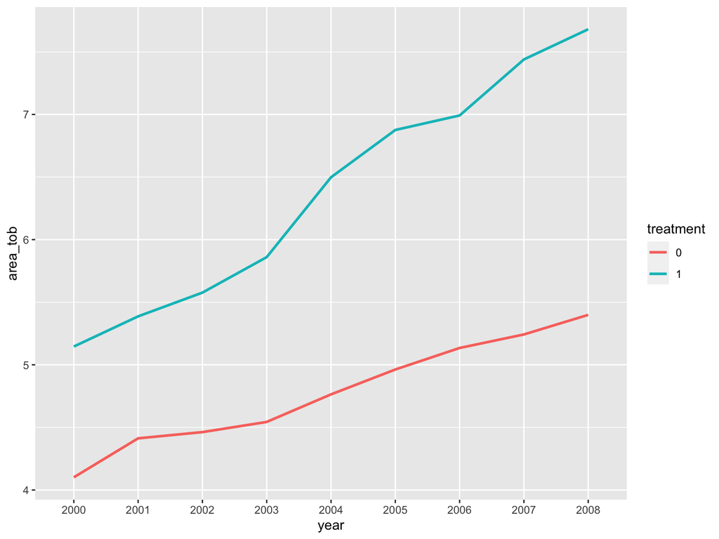

```r
ggplot(cai_data, aes(x=year, y=area_tob, color=treatment)) +
stat_summary(aes(group = treatment), fun = mean, geom = 'line', size=1)
```

- Regression-based: Estimate
  $$y_{it}=\alpha_i+\gamma_t+\sum_t \delta_{t\neq t^*} \mathbb{1}_i (i \in
  T) + \varepsilon_{it}$$
  where $t^*$ is a period before the event. Plot $\delta_t$.

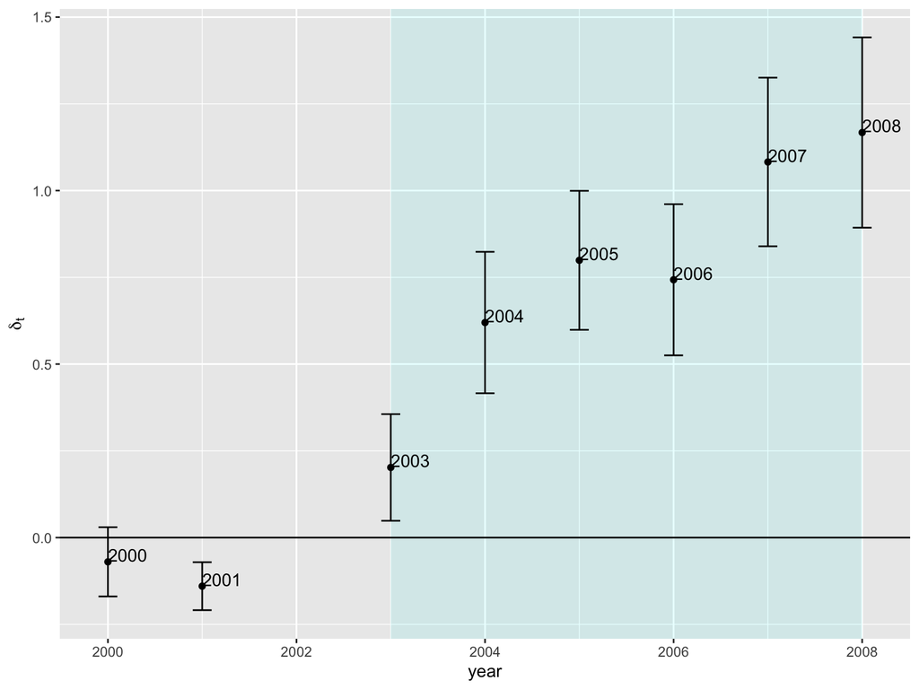

```r
#Year x treatment
DT <- sapply(2000:2008, function(l) {
   1*( (cai_data$year == l) & (cai_data$treatment == 1) )
})
DT <-as.data.frame(DT)
colnames(DT)<-c(paste0("DT",2000:2008))
cai_data<-cbind.data.frame(cai_data,DT)

#Pre-trend regression
pretrend_reg <- cai_data %>%
  plm(area_tob ~ year  + DT2000 + DT2001 + DT2003 + DT2004 + DT2005 + DT2006 + DT2007 + DT2008,
      data=., model="within",
      index=c("hhno"))
results<-coeftest(pretrend_reg, vcov=function(x) vcovHC(x, cluster=c("group")))
results<-as.data.frame.matrix(results)

#plot
plot <- tibble(
  sd = results[[2]][9:16],
  mean = results[[1]][9:16],
  year = c(2000:2001, 2003:2008))

plot %>%
  ggplot(aes(x = year, y = mean)) +
  ylab(expression(delta[t]))+
  geom_rect(aes(xmin=2003, xmax=2008, ymin=-Inf, ymax=Inf), fill = "cyan", alpha = 0.01)+
  geom_point()+
  geom_text(aes(label = year), hjust=-0.002, vjust = -0.03)+
  geom_hline(yintercept = 0) +
  geom_errorbar(aes(ymin = mean - sd*1.96, ymax = mean + sd*1.96), width = 0.2,
                position = position_dodge(0.05))
```

# Recent discussion related to “Staggered” treatment

- Different (staggered) treatment timings are nice! More variations!
- Can we still use TWFE?: Several recent papers show when and how TWFE can fail
  - de Chaisemartin and d’Haultfoeuille (2020)
  - Goodman-Bacon (2021) (or [Mixtape’s version of this](https://mixtape.scunning.com/09-difference_in_differences#twoway-fixed-effects-with-differential-timing))
  - [Guide by Callaway and Sant’Anna](https://bcallaway11.github.io/did/articles/multi-period-did.html)
  - Borusyak and Jaravel (2017)
  - Sun and Abraham (2020)
  - And recent review papers (Chaisemartin and D’Haultfoeuille (2022) and Roth et al. (2022))
- Alternatives to TWFE
  - de Chaisemartin and d’Haultfoeuille (2020): uses a weighted-average of DID estimators.
  - Callaway and Sant’Anna (2020): focuses on “group-time average treatment effect” and discusses different aggregation schemes of the group-time average treatment effect.

# de Chaisemartin and d’Haultfoeuille (2020) representation of TWFE estimator

- **Set-up** of de Chaisemartin and d’Haultfoeuille (2020) ($N_{g,t}=1$ version): Consider $N$ cross-sectional units, $i=1,...,N$, and $T>2$ time periods, $t=1,...,T$. Denote $y_{it}(d_{it})$ as potential outcomes and the treatment status, $d_{it}$, can be zero or one. The treatment effect for each $(i,t)$ is
  $$\Delta_{i,t}=y_{it}(1)-y_{it}(0).$$
  (The ATT is $\Delta=E(y_{it}(1)-y_{it}(0)|d_{it}=1)$.)
- **TWFE regression** Consider TWFE regression
  $$y_{it}=\alpha_i+\gamma_t+\tau d_{it}+\varepsilon_{it}.$$
  Do we have $E(\hat{\tau})$ converging to $E(\Delta_{i,t})$?
- **Theorem 1** of de Chaisemartin and d’Haultfoeuille (2020) (again, $N_{g,t}=1$ version)
  $$\tau=E\left(\frac{\sum_{(i,t):d_{it}=1}w_{it}\Delta_{it}}{\sum_i \sum_t
  d_{it}}\right)$$
  where
  $$w_{it}=\frac{\epsilon_{it}}{\frac{\sum_{(i,t):d_{it}=1}\epsilon_{it}}{\sum_i
  \sum_t d_{it}}},$$
  and
  $$\epsilon_{it}=d_{it}-\bar{d}_i-\bar{d}_t+\bar{d}.$$

# Why TWFE fails and when TWFE works?

- **Why TWFE fails?** $w_{it}$ does not necessary represent sample weights. Some $w_{it}$ can be **negative**!
  - In some unit-time observations, TWFE uses “treated” observations as controls… (see page 2971 of de Chaisemartin and d’Haultfoeuille (2020))
  - Negative weights are more likely to the periods when a large fraction of units are treated, and to the units who treated for many periods.
- **If $\Delta_{it}=\Delta$ (i.e. homogeneous treatment effect),** we have
  $$\tau=E\left(\frac{\sum_{(i,t):d_{it}=1}w_{it}\Delta_{it}}{\sum_i \sum_t
  d_{it}}\right)=\Delta$$
  TWFE works!
- **If $T=2$, $d_{i1}=0$ for all $i$, and $d_{i2}=1$ for some $i$,** we have $\epsilon_{i2}=\epsilon_{2}$ for $i$ with $d_{i2}=1$, and then
  $$w_{i2}=\frac{\epsilon_{2}}{\frac{\sum_{i:d_{i2}=1}\epsilon_{2}}{\sum_i
  d_{i2}}}=1$$
  TWFE works!
- Also, see Sperlich and Theler (2015). We can approach the gap between TWFE and DID as a model misspecification problem.

# de Chaisemartin and d’Haultfoeuille (2020) $DID_M$ estimator

- **The intuition**: Use the weighted average of i) “treatment effects” in groups who switch-in from $d_{it-1}=0$ to $d_{it}=1$ and ii) “treatment effects” in groups who switch-out from $d_{it-1}=1$ to $d_{it}=0$. For i), the benchmark group is $d_{it-1}=d_{it}=0$ and for ii), the benchmark group is $d_{it-1}=d_{it}=1$.
- Robust to heterogeneous treatment effects (of course, requires some assumptions such as common trend).
- **$DID_M$ estimator**
  $$DID_M=\sum_{t=2}
  \left(\theta_{\text{switch-in},t}DID_{\text{switch-in},t}+\theta_{\text{switch-out},t}DID_{\text{switch-out},t}\right)$$
  where $\theta_{\text{switch-in},t}$ and $\theta_{\text{switch-out},t}$ are shares of observations that “switch-in” and “switch-out” over total treated observations in year $t$, and
  $$DID_{\text{switch-in},t}=\frac{1}{N_{\text{switch-in},t}}\sum_{d_{it}=1,d_{it-1}=0}
  \left(y_{it}-y_{it-1}\right)-\frac{1}{N_{\text{not-treated},t}}\sum_{d_{it}=0,d_{it-1}=0}
  \left(y_{it}-y_{it-1}\right)$$
  and
  $$DID_{\text{switch-out},t}=\frac{1}{N_{\text{treated},t}}\sum_{d_{it}=1,d_{it-1}=1}
  \left(y_{it}-y_{it-1}\right)-\frac{1}{N_{\text{switch-out},t}}\sum_{d_{it}=0,d_{it-1}=1}
  \left(y_{it}-y_{it-1}\right)$$
- The paper also offers an estimator that tests for common trend assumptions. The idea is to estimate $DID_M$ for $t-1$ and $t-2$ instead of $t$ and $t-1$ (but restrict the samples to $d_{it-1}=d_{it-2}$).

# de Chaisemartin and d’Haultfoeuille (2020) $DID_M$ estimator: a simulation example

```stata
*Set up
clear all
set more off
set obs 50
*Generate panel data
set seed 1234
gen x=runiform(5,15)
sort x
gen id=_n
expand 3
bys id: gen t=_n
*Heterogeneous TEs
gen te=0
replace te=4*t if id>25
replace te=1*t if id<=25
*DGP
gen d=0
*group 1: treated in t=2 and t=3
replace d=1 if id>25 & t>=2
*group 2: treated in t=3
replace d=1 if id<=25 & t>=3
*outcome
gen e=rnormal()
gen y=0.5+0.5*t+te*d+0.2*x+e
```

```stata
*ATT (observation number-weighted)
summ te if d==1
```

```
    Variable |        Obs        Mean    Std. dev.       Min        Max
-------------+---------------------------------------------------------
          te |         75    7.666667     3.70658          3         12
```

```stata
*TWFE
xtset id t
xtreg y d i.t, fe

*de Chaisematin & DHaultfoeuille DID estimator
did_multiplegt_old y id t d, breps(100)
```

```
Panel variable: id (strongly balanced)
 Time variable: t, 1 to 3
         Delta: 1 unit


Fixed-effects (within) regression               Number of obs     =        150
Group variable: id                              Number of groups  =         50

R-squared:                                      Obs per group:
     Within  = 0.7653                                         min =          3
     Between = 0.9737                                         avg =        3.0
     Overall = 0.5797                                         max =          3

                                                F(3, 97)          =     105.44
corr(u_i, Xb) = 0.1565                          Prob > F          =     0.0000

------------------------------------------------------------------------------
           y | Coefficient  Std. err.      t    P>|t|     [95% conf. interval]
-------------+----------------------------------------------------------------
           d |   3.465396   .8524361     4.07   0.000     1.773546    5.157246
           t |
          2  |   2.681959   .6510589     4.12   0.000     1.389787     3.97413
          3  |   5.054252   .9843085     5.13   0.000     3.100672    7.007831
       _cons |   3.101676   .3480056     8.91   0.000     2.410981    3.792371
-------------+----------------------------------------------------------------
     sigma_u |  2.9108749
     sigma_e |  2.4607712
         rho |   .5832083   (fraction of variance due to u_i)
------------------------------------------------------------------------------
F test that all u_i=0: F(49, 97) = 2.85                      Prob > F = 0.0000


To estimate event-study/dynamic effects, we strongly recommend using
the much faster did_multiplegt_dyn command, available from the ssc repository.
To estimate static effects, we strongly recommend using
the much faster did_multiplegt_stat command, available from the ssc repository.
In addition to speed gains, did_multiplegt_dyn and did_multiplegt_stat
also offer more comprehensive and up-to-date options than did_multiplegt_old.

DID estimators of the instantaneous treatment effect, of dynamic treatment effects if the
dynamic option is used, and of placebo tests of the parallel trends assumption if the placebo
option is used. The estimators are robust to heterogeneous effects, and to dynamic effects if
the robust_dynamic option is used.

             |  Estimate         SE      LB CI      UB CI          N  Switchers
-------------+-----------------------------------------------------------------
    Effect_0 |  7.814228   .4890417   6.855706    8.77275         50         25
```

# Callaway and Sant’Anna (2020): Group-time average treatment effect

- **The key idea**: Think about “group-time” average treatment effect on treated.
- **Definition of “group”**: A group of units who received treatment in same time period, $G_g=1$ to indicate the group of units with the first-year of treatment is time $g$.
- **(Dynamic) potential outcomes**: A potential outcome of a unit who is in group $G_g$, i.e. who got treated *since* time $g$, is $y_{it}(g)$. Researchers observe
  $$y_{it}=y_{it}(0)+\sum_{t=2} \left(y_{it}(g)-y_{it}(0)\right)G_{ig}$$
  where $G_{ig}$ is the group indicator for unit $i$.
- **Group-time ATT**
  $$ATT(g,t)=E(y_t(g)-y_t(0)|G_g=1)$$
- **Key assumptions** in estimating *group-time ATT*
  - Conditional parallel trends based on a “Never-treated” group
  - Conditional parallel trends based on a “Not-yet-treated” group
- **Estimation**
  - **Key idea**: Compare the differences in the outcomes between time $t$ and $g-\delta-1$ where $\delta$ is the length of “anticipation” periods. You can compare $G_g=1$ with “never-treated” group or with “not-yet-treated” group. Can use outcome regression, inverse probability weighting, or doubly robust estimands. See section 2.4. of Callaway and Sant’Anna (2020).
  - **Doubly robust estimand (for the comparison to “not-yet-treated” group, assuming no anticipation)**
    $$E\left(\left(\frac{G_g}{E(G_g)}-\frac{\frac{p_{gt}(X)(1-d_{it})(1-G_g)}{1-p_{gt}(X)}}{E\left(\frac{p_{gt}(X)(1-d_{it})(1-G_g)}{1-p_{gt}(X)}\right)}\right)
    (y_{it}-y_{it-g}-m_{gt}(X)) \right)$$
    where $p_{gt}(X)$ is a propensity score for $G_g=1$, and $m_{gt}(X)$ is the difference explained by some covariates $X$.
  - Definition of **Doubly Robust**?: See Vermeulen and Vansteelandt (2015).
- **Aggregation**: It depends on what you are interested in. For example, are you interested in the average of static effects *with-in* group? Or are you interested in the *dynamic* effects measured by the length of *exposure*. See table 1 of Callaway and Sant’Anna (2020) for the discussion on “weights”.

# A potential application topic: PRF and rental rates

- Background
  1. Let’s look at the effect of staggered roll-out of the PRF Rainfall index insurance program.
  2. Here, let’s see whether having an insurance product available to ranchers affects rental rates for pastureland
     - A relevant paper is Ifft, Wu, and Kuethe (2014): Finds a positive impact on farmland values using field-level data.
  3. The data span from 2009 to 2012 ($T=4$) and the first year counties have the PRF product available differs.
  4. All counties are “treated” in 2013 and later.
- Let’s apply Callaway and Sant’Anna (2020)

```r
library(did)
library(tidyverse)
library(foreign)
library(plm)
library(lmtest)

#read data
prf_data<-read.dta("/Users/jisangyu/Dropbox/AGEC936/data/prf_rent.dta")

#TWFE
TWFE<-plm(lnvalue ~ index + as.factor(year),
          data=prf_data,
          index=c("fips"),
          model="within")
coeftest(TWFE, vcov=function(x) vcovHC(x, cluster=c("group")))
```

```
t test of coefficients:

                       Estimate  Std. Error  t value Pr(>|t|)
index               -0.00054239  0.01029714  -0.0527    0.958
as.factor(year)2010 -0.09824445  0.00596970 -16.4572   <2e-16 ***
as.factor(year)2011 -0.17075389  0.00713187 -23.9424   <2e-16 ***
as.factor(year)2012 -0.15520574  0.00768734 -20.1898   <2e-16 ***
---
Signif. codes:  0 '***' 0.001 '**' 0.01 '*' 0.05 '.' 0.1 ' ' 1
```

```r
# estimate group-time average treatment effects using att_gt method
prf_attgt <- att_gt(yname = "lnvalue",
                    tname = "t",
                    idname = "fips",
                    gname = "g",
                    panel = TRUE,
                    allow_unbalanced_panel = TRUE,
                    xformla= ~prec+prec2+tAvg,
                    control_group = c("notyettreated"),
                    anticipation=0,
                    data = prf_data
)
# summarize the results
summary(prf_attgt)
```

```
Call:
att_gt(yname = "lnvalue", tname = "t", idname = "fips", gname = "g",
    xformla = ~prec + prec2 + tAvg, data = prf_data, panel = TRUE,
    allow_unbalanced_panel = TRUE, control_group = c("notyettreated"),
    anticipation = 0)

Reference: Callaway, Brantly and Pedro H.C. Sant'Anna.  "Difference-in-Differences with Multiple Time Periods." Journal of Econometrics, Vol. 225, No. 2, pp. 200-230, 2021. <https://doi.org/10.1016/j.jeconom.2020.12.001>, <https://arxiv.org/abs/1803.09015>

Group-Time Average Treatment Effects:
 Group Time ATT(g,t) Std. Error [95% Simult.  Conf. Band]
     2    2   0.0422     0.0321       -0.0412      0.1256
     2    3   0.2063     0.0467        0.0848      0.3277 *
     2    4   0.1186     0.0558       -0.0264      0.2636
     3    2  -0.0072     0.0846       -0.2271      0.2128
     3    3   0.3464     0.0925        0.1061      0.5867 *
     3    4  -0.2404     0.0676       -0.4160     -0.0648 *
     4    2  -0.0639     0.1020       -0.3290      0.2012
     4    3  -0.1126     0.0483       -0.2381      0.0129
     4    4  -0.0026     0.0848       -0.2230      0.2179
---
Signif. codes: `*' confidence band does not cover 0

P-value for pre-test of parallel trends assumption:  0.06582
Control Group:  Not Yet Treated,  Anticipation Periods:  0
Estimation Method:  Doubly Robust
```

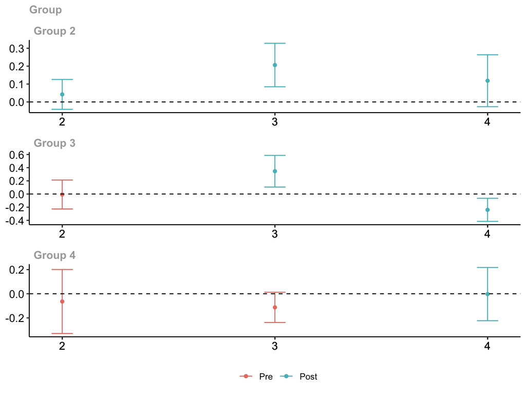

```r
# plot the results
ggdid(prf_attgt)
```

```r
# group-specific effects
agg.gs <- aggte(prf_attgt, type = "group")
summary(agg.gs)
```

```
Call:
aggte(MP = prf_attgt, type = "group")

Reference: Callaway, Brantly and Pedro H.C. Sant'Anna.  "Difference-in-Differences with Multiple Time Periods." Journal of Econometrics, Vol. 225, No. 2, pp. 200-230, 2021. <https://doi.org/10.1016/j.jeconom.2020.12.001>, <https://arxiv.org/abs/1803.09015>


Overall summary of ATT's based on group/cohort aggregation:
   ATT    Std. Error     [ 95%  Conf. Int.]
 0.064        0.0367    -0.0079      0.1358


Group Effects:
 Group Estimate Std. Error [95% Simult.  Conf. Band]
     2   0.1224     0.0348        0.0414      0.2034 *
     3   0.0530     0.0662       -0.1010      0.2070
     4  -0.0026     0.0858       -0.2023      0.1972
---
Signif. codes: `*' confidence band does not cover 0

Control Group:  Not Yet Treated,  Anticipation Periods:  0
Estimation Method:  Doubly Robust
```

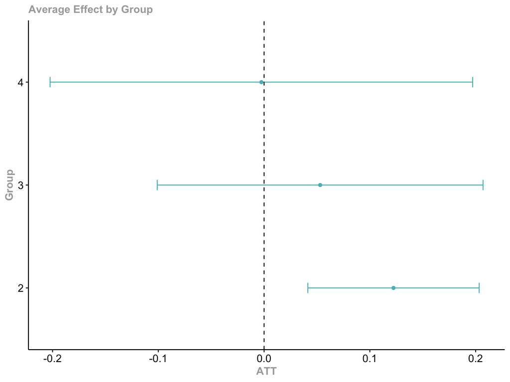

```r
# plot
ggdid(agg.gs)
```

```r
# dynamic effects
agg.es <- aggte(prf_attgt, type = "dynamic")
summary(agg.es)
```

```
Call:
aggte(MP = prf_attgt, type = "dynamic")

Reference: Callaway, Brantly and Pedro H.C. Sant'Anna.  "Difference-in-Differences with Multiple Time Periods." Journal of Econometrics, Vol. 225, No. 2, pp. 200-230, 2021. <https://doi.org/10.1016/j.jeconom.2020.12.001>, <https://arxiv.org/abs/1803.09015>


Overall summary of ATT's based on event-study/dynamic aggregation:
    ATT    Std. Error     [ 95%  Conf. Int.]
 0.0798        0.0339     0.0134      0.1462 *


Dynamic Effects:
 Event time Estimate Std. Error [95% Simult.  Conf. Band]
         -2  -0.0639     0.1097       -0.3393      0.2115
         -1  -0.0450     0.0555       -0.1842      0.0942
          0   0.1593     0.0434        0.0502      0.2683 *
          1  -0.0385     0.0436       -0.1478      0.0708
          2   0.1186     0.0518       -0.0113      0.2485
---
Signif. codes: `*' confidence band does not cover 0

Control Group:  Not Yet Treated,  Anticipation Periods:  0
Estimation Method:  Doubly Robust
```

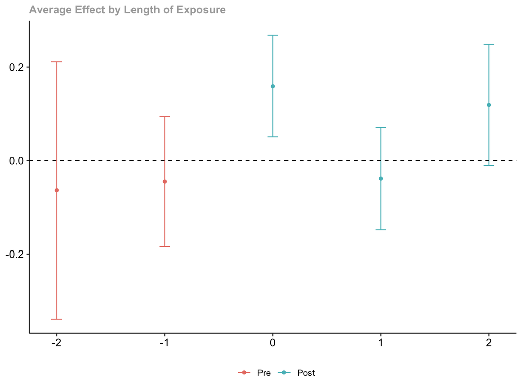

```r
# plot
ggdid(agg.es)
```

# A couple of notes on de Chaisemartin and d’Haultfoeuille (2020) vs Callaway and Sant’Anna (2020)

- de Chaisemartin and d’Haultfoeuille (2020) allows “switch-out” whereas Callaway and Sant’Anna (2020) works with strictly “staggered” cases (irreversable treatments).
- Callaway and Sant’Anna (2020) focuses more on treatment effects dynamics whereas de Chaisemartin and d’Haultfoeuille (2020) focuses on an instantaneous treatment effect.
- Unconditional (de Chaisemartin and d’Haultfoeuille 2020) versus conditional (Callaway and Sant’Anna 2020) designs.
- Packages
  - de Chaisemartin and d’Haultfoeuille (2020): **did_multiplegt** (Stata) and **DIDmultiplegt** (R)
  - Callaway and Sant’Anna (2020): **did** (R and Stata - see [here](https://github.com/NickCH-K/did))

# Another agricultural economics example

- Yu, Goodrich, and Graven (2022)

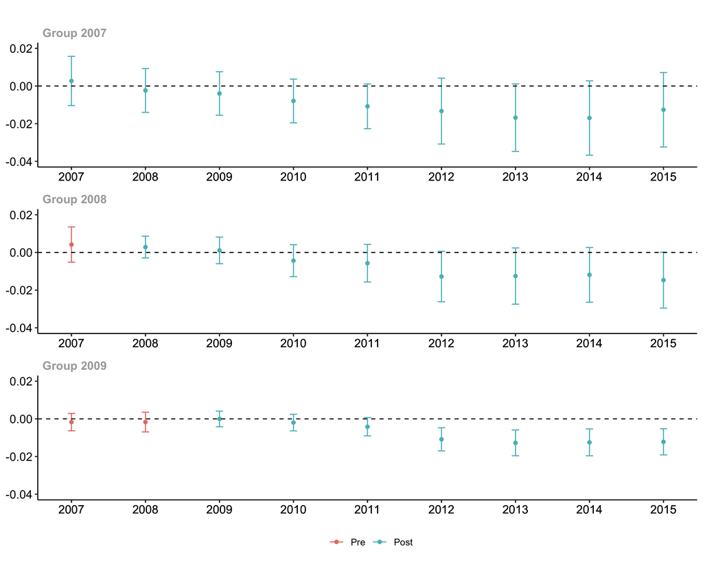

- Also see the [blog post](https://ambrook.com/research/the-conservation-reserve-program-is-competing-with-pasture-insurance-for-farmer-participation)

# Continuous (or non-binary) treatment (Callaway, Goodman-Bacon, and Sant’Anna (2021))

- Define the parameter of interest
  - Dose-response function/ATT of dose $d$
    $$ATT(d|D=d)=E(y_t(d)-y_t(0)|D=d)$$
  - Average Causal Response (ACR) a la Angrist and Imbens (1995)
    $$ACR=\frac{\partial ATE(d)}{\partial d}$$
    where
    $$ATE(d)=E(y_t(d)-y_t(0))$$
- Stronger parallel trends assumptions needed
  $$E(y_t(d)-y_{t-1}(0))=E(y_t(d)-y_{t-1}(0)|D=d) \text{ for all } d \in D$$
- Regression approach via TWFE can be misleading even with the stronger parallel trends assumptions are met. (not as severe as the staggered DID case)
- More readings on this:
  - [Summary blog post by Callaway](https://bcallaway11.github.io/posts/five-minute-did-continuous-treatment)
  - Fuzzy DID: De Chaisemartin and d’Haultfoeuille (2018)
  - Linear panel/exposure variations: Sun and Shapiro (2022)
  - General cases for Continuous treatment/DID: Callaway, Goodman-Bacon, and Sant’Anna (2021) and Chaisemartin et al. (2022)

# Next week

[Panel Time Series/Synthetic Control](https://jisangyu-agecon.github.io/AGEC936/Lectures/AGEC936_Synth_Panel_time_series.html)

# References

Angrist, Joshua D, and Guido W Imbens. 1995. “Two-Stage Least Squares Estimation of Average Causal Effects in Models with Variable Treatment Intensity.” *Journal of the American Statistical Association* 90 (430): 431–42.

Borusyak, Kirill, and Xavier Jaravel. 2017. “Revisiting Event Study Designs.” *Available at SSRN 2826228*.

Cai, Jing. 2016. “The Impact of Insurance Provision on Household Production and Financial Decisions.” *American Economic Journal: Economic Policy* 8 (2): 44–88.

Callaway, Brantly, Andrew Goodman-Bacon, and Pedro HC Sant’Anna. 2021. “Difference-in-Differences with a Continuous Treatment.” *arXiv Preprint arXiv:2107.02637*.

Callaway, Brantly, and Pedro HC Sant’Anna. 2020. “Difference-in-Differences with Multiple Time Periods.” *Journal of Econometrics*.

Chaisemartin, Clément de, and Xavier D’Haultfoeuille. 2022. “Two-Way Fixed Effects and Differences-in-Differences with Heterogeneous Treatment Effects: A Survey.” National Bureau of Economic Research.

Chaisemartin, Clément de, Xavier d’Haultfoeuille, Félix Pasquier, and Gonzalo Vazquez-Bare. 2022. “Difference-in-Differences Estimators for Treatments Continuously Distributed at Every Period.” *arXiv Preprint arXiv:2201.06898*.

De Chaisemartin, Clément, and Xavier d’Haultfoeuille. 2018. “Fuzzy Differences-in-Differences.” *The Review of Economic Studies* 85 (2): 999–1028.

de Chaisemartin, Clément, and Xavier d’Haultfoeuille. 2020. “Two-Way Fixed Effects Estimators with Heterogeneous Treatment Effects.” *American Economic Review* 110 (9): 2964–96.

Goodman-Bacon, Andrew. 2021. “Difference-in-Differences with Variation in Treatment Timing.” *Journal of Econometrics* 225 (2): 254–77.

Ifft, Jennifer, Shang Wu, and Todd Kuethe. 2014. “The Impact of Pasture Insurance on Farmland Values.” *Agricultural and Resource Economics Review* 43 (3): 390–405.

Rambachan, Ashesh, and Jonathan Roth. 2019. “An Honest Approach to Parallel Trends.”

Roth, Jonathan. forthcoming. “Pre-Test with Caution: Event-Study Estimates After Testing for Parallel Trends.” *American Economic Review: Insights*, forthcoming.

Roth, Jonathan, Pedro HC Sant’Anna, Alyssa Bilinski, and John Poe. 2022. “What’s Trending in Difference-in-Differences? A Synthesis of the Recent Econometrics Literature.” *arXiv Preprint arXiv:2201.01194*.

Rubin, Donald B. 1974. “Estimating Causal Effects of Treatments in Randomized and Nonrandomized Studies.” *Journal of Educational Psychology* 66 (5): 688.

Sperlich, Stefan, and Raoul Theler. 2015. “Modeling Heterogeneity: A Praise for Varying-Coefficient Models in Causal Analysis.” *Computational Statistics* 30: 693–718.

Sun, Liyang, and Sarah Abraham. 2020. “Estimating Dynamic Treatment Effects in Event Studies with Heterogeneous Treatment Effects.” *Journal of Econometrics*.

Sun, Liyang, and Jesse M Shapiro. 2022. “A Linear Panel Model with Heterogeneous Coefficients and Variation in Exposure.” *Journal of Economic Perspectives* 36 (4): 193–204.

Vermeulen, Karel, and Stijn Vansteelandt. 2015. “Bias-Reduced Doubly Robust Estimation.” *Journal of the American Statistical Association* 110 (511): 1024–36.

Yu, Jisang, Brittney Goodrich, and Atticus Graven. 2022. “Competing Farm Programs: Does the Introduction of a Risk Management Program Reduce the Enrollment in the Conservation Reserve Program?” *Journal of the Agricultural and Applied Economics Association* 1 (3): 320–33.